# Biweekly report: Functionalised graphene for polymer composites

Emil Tveden Bjerglund

12 dec 2017

Several groups have shown great interest in our work with production of functionalised graphene for polymer composites.

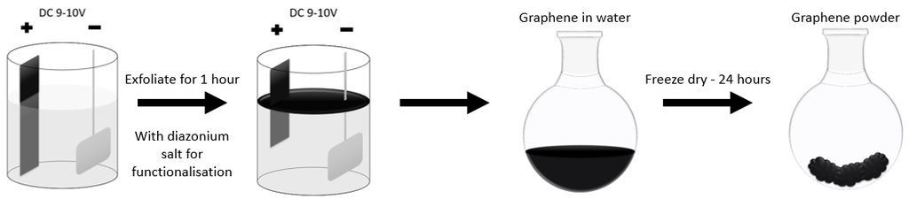

In this project we will attempt to produce batches for testing in various companies with various goals:

- Radisurf (Intends to do ATRP-polymerisation on the graphene and embed it in silicone).
- SP Group (Interest in testing it for their PUR products).
- Newtec (Interest in graphene with different functionalities for better interaction with their quantum dots).
- Chemical Engineers, AU (Repetition of our work in Andreas’ bachelorproject for potential publication).

These projects will hopefully give some more experience in handling large quantities of graphene and give some interesting applications.

Lab journal available at https://emiltb.github.io/graphene-production/lab_journal.html

# Planned experiments from last biweekly report

- Make and discuss a more detailed plan for collaboration with the chemical engineers.
- Produce new graphene for Radisurf and SP Group
- Control experiments with graphene production in 0 mM and 10 mM diazonium salt, to gain more knowledge about the observed Raman peaks.

# Synthesis of diazonium salt (scale up)

To produce graphene in solutions with higher diazonium concentrations I needed a lot more diazonium compound. Therefore the synthesis was repeated with 2 gram starting material. The solution of the aniline was a lot more prone to make a precipitate, which caused the reaction to run less cleanly. However, <sup>1</sup>H-NMR and IR confirms the presence of the expected product. I have been unable to confirm the product using ESI-MS. The expected m/z is 74.5471, and it seems that so low masses are not recorded in the spectrum I recieve.

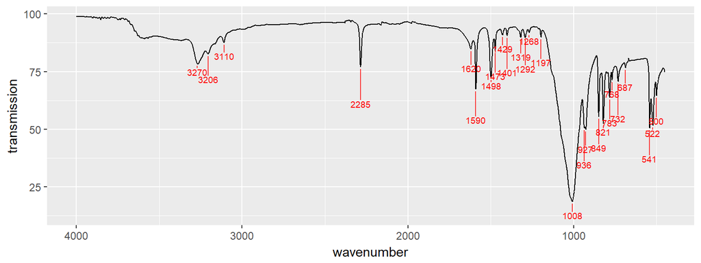

Peaks at 3270, 3206 and 1620 cm<sup>-1</sup> confirms the amine and 2285 cm<sup>-1</sup> shows the presence of diazonium groups. The large peak at 1008 cm<sup>-1</sup> could be from $BF_4^-$ acting as a counter ion for both $-N_2^+$ and $-NH_3^+$. From NMR it is clear that the amine must be protonated as it equals roughly 3H.

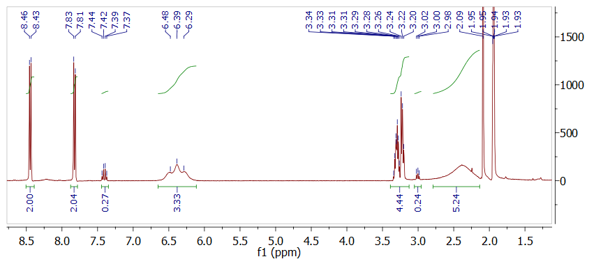

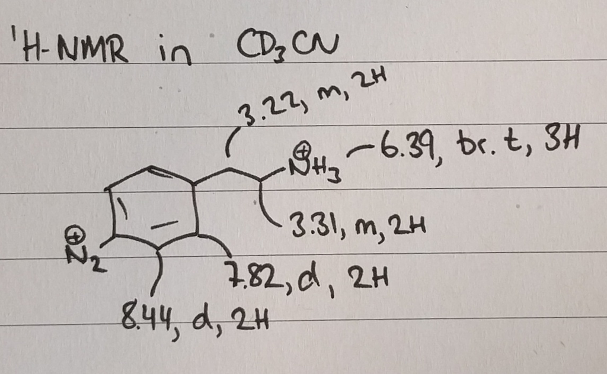

I have not been able to identify the broad impurity at 2.4 ppm, but have decided to continue with the compound nonetheless. It was not present in the small scale synthesis I did, but may be it is related to amine starting material that did not dissolve properly in HBF<sub>4</sub>. This explanation is, however, contradicted by the other signals in the H-NMR from the starting material (at 7.4 and 3.0 ppm), for which the integrals seems not to match.

# Graphene production in new electrochemical cell with active cooling

## Experimental setup

In the last biweekly report I identified a clear problem with heating of the solvent during electrochemical exfoliation. This caused the diazonium salt to degrade a long time before the exfoliation was complete. For this reason I have the workshop make a stainless steel tube, through which I can flow cold ethanol from Steens old cooling machine through. At the same time, they helped make better connections to the electrodes, so I can now attach 3-4 wires in parallel, making everything work at more appropriate temperatures when drawing 20 A through the system.

## Results and Discussion

Under these conditions, every sample extracted reveal a clear spectrum of the azo-dye.

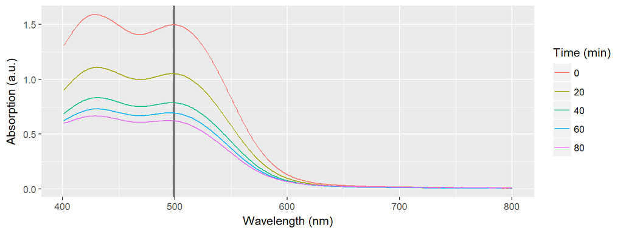

Using the previously determined extinction coefficient for the azo-dye, it is possible to find the concentration of the diazonium salt throughout the experiment. Here this is plotted together with data from a previous production where 1 mM diazonium salt was used in a system without active cooling.

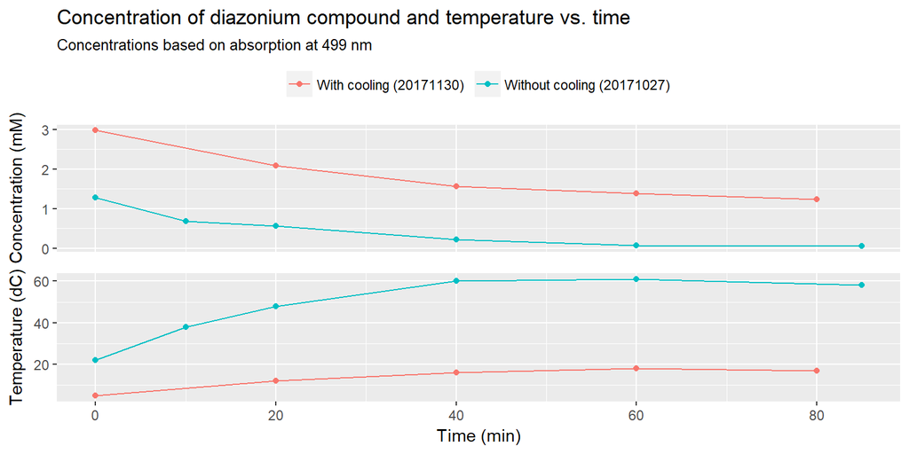

The cooling system made it possible to keep the temperature below 20 °C at all times. In this modified setup it is clearly possible to keep the diazonium compound present for the entire duration of the exfoliation. Keeping the solution cool might also have a positive influence on the degree of oxidation of the graphene.

# Conclusion

The graphene has not been isolated yet, so I cannot conclude on the quality of the product in this biweekly. However, the method seems solid and in the new setup it was quite easy to quickly exfoliate 6 grams of graphite. It will be interesting to see what the yield is and what degree of functionalisation is obtained.

Raman spectroscopy and XPS will follow as soon as possible.

# Plan for the next two weeks

- Isolate the current batch of graphene and analyse it.
- Given that this production is succesful, I just need to run several more of the same as quickly as possible to deliver to Radisurf, SP Group and the Chemical Engineers.